# Week 5: Linear models v20262909b

**Content:**

- Part 1: Linear Regression in 1D
- Part 2: Fitting non-linear data with Linear Regression in 1D
- Part 3: Linear regression on the Wine dataset
- Part 4: Logistic regression (from first principles) on the Wine dataset
- Assignment 5: Linear models on the Whisky dataset

**Objective:** become familiar with fitting linear regression models in Python.

```python
import numpy as np
import pandas as pd

import matplotlib.pyplot as plt
import sklearn.linear_model as lm
import seaborn as sns

# Plotting style
sns.set_style('darkgrid')
sns.set_theme(font_scale=1.)
```

## Introduction

Regression is widely used in data mining and machine learning for predicting an output (dependent variable) for a data object given its attributes. Regression can be defined as the task of learning a target function that maps a set of attributes onto an output. In other words, regression is a *supervised learning* techniques that generalizes from known examples.

We will initially consider a linear regression problem with the goal of modeling the outputs, $\boldsymbol{y}=\left[y_1, y_2, \dots, y_N\right]^\top$, based on a single attribute for each of $N$ data objects, $\boldsymbol{X}=\left[x_1, x_2, \dots, x_N\right]^\top$. To do this, we consider the model $$ \begin{equation*} y_n=w_0+w_1x_n+\epsilon_n, \end{equation*} $$ where $\epsilon_n$ is residual noise, $w_0$ a constant offset and $w_1$ the linear coefficient for $x_n$. We can write an equation for the target $y_n$ for each data object as $$ \begin{aligned} y_1&=w_0+w_1x_1+\epsilon_1\\ y_2&=w_0+w_1x_2+\epsilon_2\\ &\qquad \qquad \vdots \\ y_N&=w_0+w_1x_N+\epsilon_N.\\ \end{aligned} $$

We can think of the $n$'th equation as a vector product between the fixed true weight vector, $\boldsymbol{w} = \left[ w_0 , w_1 \right]^\top$, and the modified data point, $\tilde{\boldsymbol{x}}_n = \left [ 1, x_n \right ]^\top$. We can collect all modified data points in the matrix $\tilde{\boldsymbol{X}} = \left [ \bf{1} , \boldsymbol{x} \right ]$ where $\mathbf{1} = \left[ 1, 1, \dots , 1 \right]^\top$ is a vector of $N$ ones which allows us to compactly write the equations in matrix-vector form as $$ \begin{equation*} \boldsymbol{y} = \tilde{\boldsymbol{X}} \boldsymbol{w} + \boldsymbol{\epsilon} \end{equation*} $$

## Part 1: Linear Regression in 1D

First, we will fit a simple linear regression model to 1-dimensional data generated by the following relation: $$ y_n = -0.5 + 0.01 \cdot x_n + \epsilon_n, \quad \epsilon_n \sim \mathcal{N}\left(0, 0.1\right) $$

Each of the $n$ attribute values $x_n$ should be set to $x_1\!\!=\!0, x_2\!\!=\!1, x_3\!\!=\!2, \dots, x_N\!\!=\!N-1$ and $\epsilon_n$ describes the observation noise.

**Task 1.1:** Create a function `generate_data` that returns $N$ samples of this 1D dataset in the range $x\in[0,N-1]$. Plot the generated samples and the true noise-free function.

> *Hint*: You can use `np.arange` to make a sequence of integers.

> *Hint*: You can generate random numbers from a univariate Normal distribution using the function `np.random.normal`.

> *Hint*: It’s a good idea to use `.reshape(-1, 1)` on `X`, `y` and `eps` to get row-vectors. This ensures compatibility with the formulas from the course.

```python
def generate_data(w=(-0.5, 0.01), N=100, eps_std=0.1, seed=0):
    np.random.seed(seed)

    # YOUR CODE HERE
    raise NotImplementedError()

    return X, y, eps

# Plotting the generated data
N = 100                     # number of data objects
eps_std = 0.1               # observation noise parameter
w = (-0.5, 0.01)            # parameters of the linear relation

# Generate data with your function
X, y, eps = generate_data(eps_std=eps_std, w=w, N=N, seed=0)

# Get the true output values without noise
# YOUR CODE HERE
raise NotImplementedError()

# Plot original data and the model output
f = plt.figure()
plt.plot(X, y, ".", label="Training data")
plt.plot(X, y_true, "-", label=f"Data generator, $w={w}$")
plt.xlabel("X")
plt.ylabel("y")
plt.legend()
plt.show()
```

[output not shown]

Generally, in real life problems, we do not know the true coefficients generating the data. Our goal is therefore to *estimate* the coefficients, $w_0$ and $w_1$, from the data observations under the assumption that the data-generating process is linear. For doing so, we minimise the least squares error function, i.e. $$ \begin{equation*} \boldsymbol{w}^\ast = \begin{bmatrix} w_0^\ast \\ w_1^\ast \end{bmatrix} = \arg\min_{w_0, w_1} \sum_{n=1}^N \left(y_n-\left(w_0+w_1x_n\right)\right)^2=\arg\min_{w_0, w_1} \left\|\boldsymbol{y} - \tilde{\boldsymbol{X}} \boldsymbol{w} \right\|_F^2. \end{equation*} $$ Solving this optimization problem, the optimal parameter estimate has the closed-form expression $$ \boldsymbol{w}^\ast = \left(\tilde{\boldsymbol{X}}^\top \tilde{\boldsymbol{X}}\right)^{-1} \tilde{\boldsymbol{X}}^\top \boldsymbol{y} $$ Based on the estimated parameters we can predict the value of an unobserved output $y^\ast$ from an observed measurement $x^*$ as $$ \begin{equation*} y_\ast = \left[\begin{array}{c} 1 & x_\ast \end{array} \right] \left[ \begin{array}{c} w^\ast_0 \\ w^\ast_1\end{array} \right] = \boldsymbol{x}_\ast^\top \tilde{\boldsymbol{w}}^\ast \end{equation*} $$

**Task 1.2:** Fit a linear model to the data points and plot the estimated model on top of the data and true function.

> *Hint*: First create `X_tilde` by adding to `X` a column of ones. This allows you to compute `w_star`, by using `np.linalg.solve`. Finally, `y_est`is obtained by multiplying `X_tilde`and `w_star`.

> **Optional:** Try using sklearn's `sklearn.linear_model.LinearRegression` as an alternative. Do the two methods agree?

```python
# YOUR CODE HERE
raise NotImplementedError()

# Plotting the generated data along with the true data generator and the estimated model
f = plt.figure()
plt.plot(X, y, ".")
plt.plot(X, y_true, "-")
plt.plot(X, y_est, "-")
plt.xlabel("X")
plt.ylabel("y")
plt.legend(["Training data", f"Data generator, $w={w}$", f"Regression fit (model), w = {np.round(w_star,3)}"])
plt.show()
```

**Task 1.3:** Explain how the model estimates the parameters, $w_0$ and $w_1$, from the data you have generated.

- *Answer:*

**Task 1.4:** Explain why the estimated parameters are close, but not exactly equal, to the parameters used to generate the data.

- *Answer:*

**Task 1.5:** Go back and play around with the number of data samples, `N`, and the noise variance, `eps_std`. How can you get the estimated model parameters closer to the actual parameters used to generate the data?

## Part 2: Fitting non-linear data with a linear model - linear Regression in 1D

Sometimes there are more complex relationships between the attributes and output. In order to capture more complex relationships we can include attributes that are specified transformations of existing attributes such as $\sqrt{x}$, $\log{(x)}$, $x^2$ and $x^3$.

We will presently consider the model

\begin{equation*} y_n = w_0 + \sum_{k=1}^{K} w_k x_n^k + \epsilon_n. \end{equation*}

You can see this as a generalisation of Part 1, where $K=1$.

The above model can again be written for all $N$ observations simultaneously in terms of vectors and matrices, i.e.

$$ \boldsymbol{y} = \left[\boldsymbol{1}\ \boldsymbol{x}^1\ \boldsymbol{x}^2\ \dots\ \boldsymbol{x}^{K}\right] \begin{bmatrix} w_0 \\ w_1 \\ w_2 \\ \vdots \\ w_{K} \end{bmatrix} + \boldsymbol{\epsilon} = \left[\boldsymbol{1}\ \boldsymbol{X}\right] \boldsymbol{w} + \boldsymbol{\epsilon} $$

where $\boldsymbol{x}^{k}=\left[ x_1^{k}, x_2^{k}, \dots, x_N^{k}\right]^\top$.

**Task 2.1:** Create a function `generate_data` that returns $N$ samples of this dataset in the range $x\in[-2,2]$. The function should allow you to specify how many $K$ terms to include (squared, cubed, etc.) for generating the data.

> *Hint*: You can use `np.linspace()` to make a sequence of real numbers.

> *Hint*: See the function `np.power()` that can raise the content of a vector/matrix to a specified order.

**Task 2.2:** Generate $N=50$ samples with $\boldsymbol{w} = -\begin{bmatrix}-0.9 & -0.9^2 & \dots & -0.9^{K+1}\end{bmatrix}^\top$ for $K=5$. Plot the generated samples and the true function in the range $x\in[-2,2]$ with a higher resolution on the x-axis.

```python
def generate_polynomial_data(w, K_data, eps_std, seed=0):
    np.random.seed(seed)

    # YOUR CODE HERE
    raise NotImplementedError()

    return X, y, eps


# Parameters
N = 50                      # no of data objects to train a model
K_data = 5                  # no of terms for data generator
eps_std = 0.5  # noise parameters

# Define the true parameter vector
# YOUR CODE HERE
raise NotImplementedError()

# Generate data with your function
X, y, eps = generate_polynomial_data(w=w_true, K_data=K_data, eps_std=eps_std, seed=0)

# Sampling 1000 points to visualize the true data and model
N_est = 1000
X_est = np.linspace(-2, 2, 1000).reshape(-1, 1)

# Define the true data generator function, y_true (assuming no noise)
# YOUR CODE HERE
raise NotImplementedError()

# Plot original data and the model output
f = plt.figure()
plt.title("Illustration of generated data with noise, and the true data generator")
plt.plot(X, y, ".", label="Training data")
plt.plot(X_est, y_true, "-", label=f"Data generator K={K_data}")
plt.xlabel("X")
plt.ylabel("y")
plt.ylim(-2, 8)
plt.legend()
plt.show()
```

We now want to fit a model with polynomial terms of order $K_{m}$ to the data generated above. The models output can be formulated as $$ \begin{equation*} y_n = w^\ast_0 + \sum_{k=1}^{K_m} w^\ast_k x_n^k \qquad \text{or} \qquad \boldsymbol{y} = \tilde{\boldsymbol{X}} \boldsymbol{w}^\ast \end{equation*} $$ for $N$ observations where $\tilde{\boldsymbol{X}} = \left[\boldsymbol{1}, \boldsymbol{x}, \boldsymbol{x}^2, \dots, \boldsymbol{x}^{K_m} \right]$. Remark the difference between the order of the model, $K_m$, and the order of the data, $K$. This model can fit non-linear trend of the data but is *still linearly dependent on the model weights*. The overall formulation is therefore exactly the same as before for which we know how to compute the coefficients.

**Task 2.2:** Estimate the model parameters for a model with polynomial order of $K_{m} = 3$. Plot the estimated model on top of the generated data samples and true model.

> *Hint*: Use `X` to create a matrix `X_tilde` and use it for model fitting.

> *Hint*: Use `X_est`to create a matrix `X_est_tilde` and use it for model prediction.

> *Hint*: Consider the formula $$w^*=(\tilde{\boldsymbol{X}}^\top\tilde{\boldsymbol{X}})^{-1}\tilde{\boldsymbol{X}}y,$$ which can be found in Chapter 8 of your textbook.

```python
K_model = 3

# Fit the model with polynomial features up to degree K_model and estimate the outputs as y_est
# YOUR CODE HERE
raise NotImplementedError()

# Plot original data and the model output
f = plt.figure()
plt.plot(X, y, ".", label = "Training data")
plt.plot(X_est, y_true, "-", label = f"Data generator K={K_data}")
plt.plot(X_est, y_est, "-", label = f"Regression fit (model) for K={K_model}")
plt.xlabel("X")
plt.ylabel("y")
plt.ylim(-2, 8)
plt.legend()
plt.show()

print(f"Estimated parameters: {w_star.flatten()}")
```

**Task 2.3:** Play around with the parameters of the experiment and reflect on how they impact the model fit.

- How well does the model fit the data points? How well does the model fit the true underlying function?
- What happens when fitting a model with more higher order terms, e.g. $K_m=10$ or $K_m=25$? Do you see any potential problems when setting $K_m$ too high?
- Try increasing the number of samples to $N=1000$ while keeping the $K_m=25$. How does this impact the model fit? How did this impact the potential problem?

## Part 3: Linear regression on the Wine dataset

We will now take a look at the wine data set and attempt to predict the alcohol content (given in percentage) using linear regression. The linear regression model we consider is

$$ \begin{equation*} y_n=w_0+\sum_k w_kx_{n,k}+\epsilon_n, \end{equation*} $$ where $y_n$ is the observed alcohol content, $\epsilon_n$ the model residual, $w_k$ the value of the estimated model coefficient for the $k^{th}$ attribute, whereas $x_{n,k}$ denotes the $n^{th}$ observation of the $k^{th}$ attribute. As such, $x_{2,1}$ denotes the second observation of the first attribute (Fixed acidity) and $x_{5,2}$ the fifth observation of the second attribute (Volatile acidity).

Say we expect volatide acidity (VA) to be around $0-2 \textrm{g}/\textrm{dm}^3$, density (D) to be close to $1 \textrm{g}/\textrm{cm}^3$, and alcohol percentage (AP) to be somewhere between $5-20\% \textrm{vol}$. We can use this knowledge to define wines with VA > 2, D > 1 and AP > 20 as outliers.

**Task 3.1:** Load the Wine dataset in Pandas from the accompanied data-folder and take a look at the data structure. Remove the `"Quality score (0-10)"`-column as well as potential outliers.

> *Hint:* Use `pd.read_csv`, `df.drop()` and `df.head()`

> *Hint:* Pandas allows for logical conditions like `(df['Alcohol'] > 20)` to identify rows with outliers. Combine multiple conditions using the `|` operator (logical OR), and wrap each condition in parentheses. To remove the outliers, consider using the `~` operator to invert the filter.

```python
# Load the wine dataset in pandas DataFrame
# YOUR CODE HERE
raise NotImplementedError()

print(df.shape)
df.head()
```

Originally the dataset is used for binary classification on red vs. white wines, which we will also be doing with logistic regression in Part 4. For now we will consider the `Alcohol` content as our target attribute and perform a linear regression using the remaining attributes.

**Task 3.3:** Pick the correct columns of the dataframe, to construct your `X` and `y` matrices containing input attributes and target attributes for the task.

```python
# YOUR CODE HERE
raise NotImplementedError()
```

**Task 3.4:** Fit a linear model of the data points and calculate the residuals. Collect the estimated parameters in a vector (as previously) and plot the estimated model.

> *Hint:* You can use the formula from Task 2.2 to compute $w^*$.

> *Hint:* Which values `y_est` does the model predict for $X$? The residual will be the difference between `y_est`and the true `y`.

```python
# Fit regression model to the wine dataset
# YOUR CODE HERE
raise NotImplementedError()

# Display scatter plot and histogram of residuals
fig, axs = plt.subplots(2, 1, figsize=(8, 8))
axs[0].scatter(y, y_est, marker='.', alpha=0.5)
# Add x = y line
min_val = min(y.min(), y_est.min())
max_val = max(y.max(), y_est.max())
axs[0].plot([min_val, max_val], [min_val, max_val], 'r-', linewidth=2)

axs[0].set_xlabel("Alcohol content (true)")
axs[0].set_ylabel("Alcohol content (estimated)")
axs[0].set_title("Scatter plot of true vs estimated alcohol content")
axs[1].hist(residual, bins=40, alpha=0.7)
axs[1].set_xlabel("Residuals")
axs[1].set_ylabel("Frequency")
plt.show()

# Estimated parameters, and their attribute names
print("\033[1mEstimated parameters:\033[0;0m")  # Bold text for emphasis
print(f"Intercept: {w_star[0].item():.3f}")
for i, name in enumerate(X.columns):
    print(f"{name}: {w_star[i+1].item():.3f}")


print(f"\nMSE: {np.mean(residual**2):.3f}")
```

**Task 3.5** Explain what the visualisations tell you about the accuracy of the prediction.

- *Answer:*

**Task 3.6:** Argue from the estimated parameters of the linear regression model that wines with higher alcohol content in general have lower density. Consider verifying it with a small code example: you can take a random wine from the dataset and call it `example`. You then create 100 copies and let the density value vary between `X['Density'].min()`and `X['Density'].max()`. Using your model, you now predict the alcohol value for these new samples.

- *Answer:*

```python
example = X.iloc[0, :]
# Create a dataframe with many copies of the example
example = pd.DataFrame([example] * 100, columns=X.columns)
# Define a realistic density range
density_vals = np.linspace(X['Density'].min(), X['Density'].max(), 100)
# replace the dummy density attribute with the range
example['Density'] = density_vals.flatten()

# YOUR CODE HERE
raise NotImplementedError()
# Plot the estimated alcohol content as a function of Density
fig = plt.figure()
plt.title("Estimated alcohol content as a function of Density")
plt.plot(density_vals, alc_predict)
plt.xlabel("Density")
plt.ylabel("Alcohol content (estimated)")
plt.show()
```

**Task 3.7:** Go back to where you defined your data matrix `X`. How does the following affect the performance of your linear regression model (try modifiying you code to do this)?

- Standardization of the input attributes.
- Standardization of the target attribute.
- Adding a new feature that is pure noise.
- Adding a new feature that is very similar to an existing one. E.g. do `X['new-pH'] = X['pH'] + 0.01 * np.random.randn(X.shape[0])`

As we saw in Part 2, specific data attributes can have a non-linear relationship with the output and we need to consider if specific transformations of attributes can capture such non-linear patterns effectively. For determining if there are any obvious transformations, we take a closer look at the wine data set.

**Task 3.8:** Create a figure with subplots that shows each attribute against the alcohol content as scatter plots. Create a similar figure showing each attribute against the model residual.

```python
# YOUR CODE HERE
raise NotImplementedError()
```

**Task 3.9:** Argue what transformations could be useful for making the linear assumption of the regression model more appropriate. Construct a new data matrix `X_tilde` and fit a linear regression model to the transformed wine data. Compute the mean-squared error (MSE) and plot each transformed attribute vs. the residual as scatter plots.

> *Hint*: Feel free to iterate - how low can you get the MSE?

> *Hint*: Plots of attributes versus the model residuals can help reveal if there is structure in the output that can be explained by transformations of the attributes.

> *Hint*: You can use `np.log()`, `np.power()`, `np.multiply()`, etc. on appropriate columns of data matrix.

> *Hint*: The `np.bmat()` function is useful to concatenate matrices and/or vectors.

```python
# YOUR CODE HERE
raise NotImplementedError()
```

## Part 4: Logistic regression on the Wine dataset

Until now we have discussed the most simple linear model based on the squared error cost function. In the generalized linear model, we can also use other loss/cost functions as well as non-linear link functions.

It can be very useful to limit the possible outputs to the range $(0,1)$ if the outputs we wish to predict are binary. Predicting binary outputs is what we have previously referred to as binary classification and generalized linear models can thus both be used for regression and classification.

For outputs that are purely binary, $y\in\{0,1\}$, we can use the logistic function, $\sigma(x)=\frac{1}{1+\exp(-x)}$, as the non-linear link function. This function maps the output in the regression analysis to the range $(0,1)$ and ensures that $\sigma(x) = 1 - \sigma(x)$. You can read more about the logistic function [here](https://en.wikipedia.org/wiki/Logistic_function).

Classification with a likelihood function based on the Bernoulli distrbution and logistic link function is called *logistic regression* (for more information [see here](https://en.wikipedia.org/wiki/Logistic_regression)). We will return to the wine data and predict the type of wine using logistic regression. The model we consider is $$ p(y_n = 1 \mid \mathbf{x}_n, \mathbf{w})=\sigma\left(w_0+\sum_k w_k x_{n, k}\right)=\sigma\left( \mathbf{w}^T\mathbf{x} \right) $$ where $p(y_n = 1 \mid \mathbf{x}_n, \mathbf{w})$ is the likelihood of observing and outcome $y=1$ where we encode the of wine with 0 and 1 (Red: $y_n=1$ and White: $y_n=0$) given the model. We will say that a wine is Red with probability $\hat p_n$ and White with probability $1-\hat p_n$. where $\hat p_n=\sigma(w_0+\sum_k w_k x_{n,k})$.

**Task 4.2:** Construct the data matrices `X` and `y` so that they are suitable for solving the binary classification problem.

> *Hint:* All you need to do here add the bias term to the data matrix; everything else is given.

```python
# Construct X and y for the classification problem, we apply the same filtering as before
df = pd.read_csv('data/wine.csv') # we load the data
df = df[~((df['Volatile acidity'] > 2) | (df['Density'] > 1) | (df['Alcohol'] > 20))] # filter
X = df.drop(columns=['Color','Quality score (0-10)']) # let's not use the quality score
y = df['Color'].values

# We count the number of types
n_red = (y == "Red").sum()
n_white = (y == "White").sum()
n_total = len(y)
print(f"# Red:   {n_red}")
print(f"# White: {n_white}")
print(f"# Total: {n_total}")

# Encode Red as 0 and White as 1
y = np.array([1 if val == 'Red' else 0 for val in y])
y = y.reshape(-1, 1)

# Std. the dataset (note we will need these values later!)
mu = X.mean(axis=0)
sig = X.std(axis=0, ddof=0)
X_std = (X - mu) / sig

# Add bias term and save as X_tilde
# YOUR CODE HERE
raise NotImplementedError()

# Print (subset) to check everything look fine
print(f"\nX_tilde = {np.array2string(X_tilde)}")
print(f"\ny = {np.array2string(y)}")
```

To do so, we will write a set of functions which finds the optimal parameter `w_star`thorugh gradient descent and predict the probability of y, $p(y_n\mid \mathbf{x_n}, \mathbf{w})$.

Recall, the setup is as follows: $ f_n=f({\boldsymbol{x}}_n;\boldsymbol{w})=\boldsymbol{w}^\top {\boldsymbol{x}}_n, \hat p_n=p(y_n=1 \mid \mathbf{x_n}, \mathbf{w})=\sigma(f_n),$ and $\sigma(z)=\frac{1}{1+e^{-z}}$.

> *Rationale*: Of course these functions are already implemented in e.g. sklearn and many other places, however we want you do know what these "toolbox" functions actually do, hence we provide the details here. You may wish to get you TA to explain the details but understanding how we get to the gradient is **not** part of the curricilum or exam.

**Tasks 4.3.1** Complete the function `my_function` that computes and return the function f evaluated at $\mathbf{x}$, i..e, value $f( \boldsymbol{x}; \boldsymbol{w})=\boldsymbol{w}^T\boldsymbol{x}$. The function must be able to compute $f$ for a matrix $\boldsymbol{X}$ and return a vector, `f_val`, as output.

```python
def my_function(X, w):
    # YOUR CODE HERE
    raise NotImplementedError()
    return f_val
```

**Task 4.3.2.** Complete the sigmoid function $\sigma(z) = \frac{1}{1 + e^{-z}}$. Save the output in `sigma`. We plot the function for you.

```python
def link_function_sigmoid(z):
    # YOUR CODE HERE
    raise NotImplementedError()
    return sigma

# We plot how it looks like
zaxis = np.linspace(-5, 5, 1000).reshape(-1, 1)
fig = plt.figure(figsize=(6, 2.5))
plt.plot(zaxis, link_function_sigmoid(zaxis))
plt.xlabel("z")
plt.ylabel(r"$\sigma(z)$")
plt.title("Logistic Link Function")
plt.show()
```

**Task 4.3.3** Complete the function `p_y_given_w_and_x` that takes `X`, `w` and `y` as inputs and returns the probabilty of y given the observation.

> - Hint: Use the `link_function_sigmoid` and `my_function` functions from above. Save and return as `p`.

```python
def p_y_given_w_and_x(w, X, y):
    # YOUR CODE HERE
    raise NotImplementedError()
    return p
```

**Task 4.3.4** We will implement a loss function that computes the loss for a single data point, effectively the negative log-likelihood of an observation given the model. We have that for an individual observation the loss is the negative log-likelihood, i.e.,

$$e_n(\mathbf{w}) = - log\,p(y_n \mid \mathbf{x}_n, \mathbf{w})$$

Complete the `loss_lr_n` function below to compute $e_n(w)$, Save as `e_n`

> *Hint* You have implemented $p(y \mid \mathbf{x}, \mathbf{w})$ in `p_y_given_w_and_x`

```python
def loss_lr_n(w,x_n,y_n):
    # YOUR CODE HERE
    raise NotImplementedError()
    return e_n
```

**Task 4.3.5** Complete the function that computes the loss for all training points $\small E(\mathbf{w}) = - \frac{1}{N} \sum_{n=1}^N log\, p(y_n \mid \mathbf{x}_n , \mathbf{w}) $

> *Note*: We some times write the loss as the binary cross-entropy $\small E(\mathbf{w})= -\frac{1}{N}\sum_{n=1}^{N}\left[y_n\log \hat p(y=1\mid \mathbf{x}_n) + (1-y_n)\log 1-\hat p(y=1\mid \mathbf{x}_n))\right].$ We have implemented the function by splitting the computation in two functions to clearly indicate what the likelihood is and what the loss is.

```python
def loss_lr(w,X,y):
    # YOUR CODE HERE
    raise NotImplementedError()
    return e
```

**Gradients of the loss function (optional, skip the first time around and go to the next task)**. We consider the gradient of the loss functio, i.e., how much does the loss change if we change the weights. This is quite math heavy and you are not expected to nessesarily understand everything except the conceptual meaning of what a gradient of a loss funciton is. If we consider the loss (derived from the likelihood) per observation which we need to optimize the the weights $\mathbf{\mathbf{w}}$: $e_n(\mathbf{w})= -\left>[y_n\log \hat p_n + (1-y_n)\log(1-\hat p_n)\right]$ and $E(\mathbf{w})=\frac{1}{N}\sum_{i=1}^N e_n(\mathbf{w}).$ where we use the shorthand notation $\hat p_n=p(y_n = 1 \mid \mathbf{x}_n)=\sigma( \mathbf{w}^T \mathbf{x}_n )$.

We exploit the chain rule and get $ \nabla_\mathbf{w} e_n(\mathbf{w})=\frac{\partial e_n}{\partial \hat p_n}\, \frac{\partial \hat p_n}{\partial f_n}\, \nabla_\mathbf{w} f_n. $ The individual terms can be extraced using basic calculus $$\small \frac{\partial e_n}{\partial \hat p_n} = -\left(y_n\frac{1}{\hat p_n}+(1-y_n)\frac{-1}{1-\hat p_n}\right) = -\frac{y_n}{\hat p_n}+\frac{1-y_n}{1-\hat p_n}. \qquad \frac{\partial \hat p_n}{\partial f_n} =\sigma'(f_n) =\sigma(f_n)\big(1-\sigma(f_n)\big) =\hat p_n(1-\hat p_n). \qquad \nabla_\mathbf{w} f_n=\nabla_\mathbf{w} (\mathbf{w}^\top \mathbf{x}_n)=\mathbf{x}_n. $$

We now get (and simplyfing a bit) $$ \nabla_\mathbf{w} e_n(\mathbf{w}) =\left(-\frac{y_n}{\hat p_n}+\frac{1-y_n}{1-\hat p_n}\right)\hat p_n(1-\hat p_n)\,\mathbf{x}_n. \qquad \left(-\frac{y_n}{\hat p_n}+\frac{1-y_n}{1-\hat p_n}\right)\hat p_n(1-\hat p_n) = -y_n(1-\hat p_n)+(1-y_n)\hat p_n = \hat p_n-y_n. $$

The final per-example gradient becomes $ \nabla_\mathbf{w} e_n(\mathbf{w})=(\hat p_n-y_n)\mathbf{x}_n =\Big(\sigma\!\big(f(\mathbf{x}_n;\mathbf{w})\big)-y_n\Big)\mathbf{x}_n. $ This is important, it tells you how much teh loss change if you change the weights based on a single observation. We are of course interested in how the loss changes across all the observations so we average the gradients accordingly (this is due to rules of differentiation) $$\small \nabla_\mathbf{w} E(\mathbf{w}) =\frac{1}{N}\sum_{i=1}^{N}\nabla_\mathbf{w} e_n(\mathbf{w}) =\frac{1}{N}\sum_{i=1}^{N}\Big(\sigma\!\big(f({\mathbf{x}}_n;\mathbf{w})\big)-y_n\Big)\mathbf{x}_n. $$

Of course we prefer the matrix form as it is more convinient: $$\small \nabla_\mathbf{w} E(\mathbf{w})=\frac{1}{N}{\mathbf{x}}^\top(\mathbf{\hat p} - \mathbf{y}). $$ where $\mathbf{y}$ are vectors of length N with the labeles and $\mathbf{\hat p}$ has the $p(y_n=1 \mid \mathbf{x}_n, \mathbf{w})$ values for all $N$ observations. **This is the equation you need to implement!**

**Task 4.3.6** Complete the function below that computes the loss and the gradient of wrt $\mathbf{w}$, i.e. $\nabla_\mathbf{w} E(\mathbf{w})=\frac{1}{N}{\boldsymbol{X}}^\top(\mathbf{\hat p} - \mathbf{y})$. Save $\nabla_\mathbf{w} E(\mathbf{w})$ in `g`.

```python
def loss_and_gradient_lr(w,X,y):
    N = X.shape[0]
    e = loss_lr(w,X,y)
    p_hat = p_y_given_w_and_x(w, X, np.ones( (N,1)) ) # to get p hat we compute p(y=1 | w, x) for all the x entries

    # YOUR CODE HERE
    raise NotImplementedError()

    return e, g
```

**Task 4.3.7** We now need an algorithm that uses the loss function and its gradient to iteratively move toward the best parameter vector $\boldsymbol{w}$. Intuitively, we "walk downhill" on the loss landscape—taking steps in the direction of steepest decrease—until we reach (a) a valley where the loss is minimal, or (b) a point where further improvement becomes negligible.

1. **Initialize parameters**: Choose an initial guess $\boldsymbol{w}^{(0)}$ (e.g., random values or zeros).
2. **Choose a learning rate** Pick a step size $\eta > 0$ (the learning rate).
3. **Iterate until convergence** (for $i = 0,1,2,\dots$)
   - 3.a) Compute the gradient:$\nabla_{\boldsymbol{w}} E\!\left(\boldsymbol{w}^{(i)}\right)$
   - 3.b) Update the parameters by stepping *against* the gradient: $\boldsymbol{w}^{(i+1)}=\boldsymbol{w}^{(i)}-\eta\,\nabla_{\boldsymbol{w}} E\!\left(\boldsymbol{w}^{(i)}\right)$ [this is the code you need to provide]
4. **Stopping criteria** Stop when small gradient norm: $\left\|\nabla E\!\left(\boldsymbol{w}^{(i)}\right)\right\| < \varepsilon$, tiny improvement in loss: $\left|E\!\left(\boldsymbol{w}^{(i+1)}\right)-E\!\left(\boldsymbol{w}^{(i)}\right)\right| < \varepsilon$ or maximum number of iterations reached. Here we will use the latter option for simplicity.

Complete the algorithm below by implementing step 3b) (one line).

```python
def fit_lr(X, y, eta=0.001, n_iter=10000, eta_adaptive=True):
    N, M = X.shape
    w = np.zeros((M, 1)) # init the weight to zero

    print("Iter\tLoss\t\t||grad||\t eta\t\t ||w||")
    print("-" * 60)
    e_prev = np.inf

    for iter in range(n_iter):
        e, gradient = loss_and_gradient_lr(w, X, y)

        # Now update the weights...
        # YOUR CODE HERE
        raise NotImplementedError()

        # We implement a simple way to control the learning rate for faster convergence
        if eta_adaptive:
            eta = eta * 0.5 if e > e_prev else eta * 1.005
            e_prev = e

        if iter % 100 == 0 or iter == n_iter - 1 or iter == 0:
            print(f"{iter}\t{e:.6f}\t{np.linalg.norm(gradient):.6f}\t{eta:.6f}\t{np.linalg.norm(w):.6f}")
    return w
```

> *Note.* Remarkably, this simple principle—minimizing a loss function by following its gradient—is what underpins modern AI and machine learning. Systems such as ChatGPT and Gemini rely on the same core idea, although with far more complex models and loss functions than the simplified setting we consider here.

**Task 4.4** We will now train/fit the logistic regression model with our simple gradient algorithm and print the weights. You do not have to write code here; just run it and inspect the output (**ask your TA to explain the details**).

```python
# First we try to fit the logistic regression model
w_star = fit_lr(X_tilde, y)

print(f"\n w*= {np.array2string(w_star.T)}")
```

**Task 4.5**: Plot the weights as a bar plot and reason about the importance of weights in the final model.

> *Hint*: Remember that we added a collumns of ones to the orginal `X`

```python
# Visualize the weigths as a bar plot
# YOUR CODE HERE
raise NotImplementedError()
```

**Task 4.6** Create a function that makes a hard prediction of whether the it is class 0 or 1. It should take the probabilities as input. and return 0 or 1 by thresholding at $p=0.5$. Save the predictions as integers in `y_est`.

```python
def predict(p, threshold=0.5):
    # YOUR CODE HERE
    raise NotImplementedError()
    return y_est

# Classify wine as White/Red (0/1) and assess probabilities
p_est = p_y_given_w_and_x(w_star, X_tilde, np.ones((X.shape[0],1)))
y_est = predict(p_est)
```

**Task 4.7:** What is visualized in the plot below?

- *Answer:*

```python
plt.figure()
class0_ids = np.nonzero(y == 0)[0].tolist()
plt.plot(class0_ids, p_est[class0_ids], ".y")
class1_ids = np.nonzero(y == 1)[0].tolist()
plt.plot(class1_ids, p_est[class1_ids], ".r")
plt.xlabel("Wine sample")
plt.ylabel("Predicted prob. of class Red (y=1)")
plt.ylim(-0.01, 1.3)
plt.legend(["White", "Red"])
```

**Task 4.8:** Compute the error rate (aka the misclassificaiton rate), `error_rate`. How does this relate to the accuracy?

```python
# Evaluate the classifier's misclassification rate over entire training data
# YOUR CODE HERE
raise NotImplementedError()

print("\nOverall misclassification rate: {0:.4f}".format(error_rate))
```

**Task 4.9:** Use the model to show that the following newly observed wine, would be classified as White wine. Do this by computing and save the probably of $p(y=1 \mid x, w)$ in `p_y_is_one_given_x_star` (i.e. the probability of a red wine).

- Fixed acidity: 6.9
- Volatile acidity: 1.09
- Citric acid: 0.06
- Residual sugar: 2.1
- Chlorides: 0.0061
- Free sulfur dioxide: 12.0
- Total sulfur dioxide: 31.0
- Density: 0.99
- pH: 3.5
- Sulphates: 0.44
- Alcohol: 12.0

> *Hint:* Use your function `p_y_given_w_and_x` and recall that we standardized the data!

```python
# Define the new wine, and evaluate its probability of being a red wine (i.e. y=1).
# YOUR CODE HERE
raise NotImplementedError()

print(f"Probability of given sample being a red wine: {p_y_is_one_given_x_star:.4f}")
```

**Task 4.10:** Go back to where you defined your data. How does the following affect the performance of your logistic regression model?

- Adding a feature that is pure noise
- Adding a feature that is very similar to an existing one. E.g. do `X['new-pH'] = X['pH'] + 0.01 * np.random.randn(X.shape[0])`
- Removing some of the features
- Not standardization of the input features (Here you would need to run the naiive optimization function for much, much longer and check that you have converged; perhaps use the method in 4.11 to do this)

**Task 4.11 (optional)**: The toolbox sklearn has an convient implementaion of logistic regression, named `sklearn.linear_model.LogisticRegression`. You should use this for actual applications instead of our custom implementation.

Try to fit the model using `sklearn.linear_model.LogisticRegression`. Do you get the same result as when using our own rather naiive implementation?

> *Hint:* `LogisticRegression` is tempting to use “as is”, but it performs several steps under the hood (regularization, intercept handling, stopping criteria, solver choices) that can obscure what’s happening when you’re first learning the algorithm. To match the model defined above as closely as possible, use:

> `LogisticRegression(max_iter=1000, fit_intercept=False, tol=1e-6, C=np.inf)`

> We’ll explain the role of `C` (and its theoretical motivation) later in the course.

```python
# Fit the logistic regression model using sklearn
# YOUR CODE HERE
raise NotImplementedError()
```

# Assignment 5:

In this assignment you will use the **Whisky dataset** again. The data in `data/whiskies.txt` (or `data/whiskies.csv`) comes from a number of whisky distilleries, with subjective judgements on flavour characteristics from [this Strathclyde University research project](https://www.mathstat.strath.ac.uk/outreach/nessie/nessie_whisky.html). Each distillery is judged on twelve flavour indicators (e.g. smokiness, sweetness) on a 0–4 scale, i.e. each distillery is a 12-dimensional feature vector.

**The main tasks**

```python
# We import everything needed for the assignment part
import matplotlib.pyplot as plt
# Plotting style
import seaborn as sns
sns.set_style('darkgrid')
sns.set_theme(font_scale=1.)

import utils as utils, re
import pandas as pd
import numpy as np

utils.reset_marks()
a,b,c,d = utils.platform_info()
print(f"Platform info: <<<{a}:{b}:{c}:{d}>>>")
with utils.marks(0): # If we get to this point, we will show a checkmark to indicate that everything looks fine so far
    assert(True)
```

```
Platform info: <<<['machine-guid:9ae31c38-5105-4f45-9304-7394df884529', 'mac:d4d8537ed9ec', 'node:DESKTOP-RA3GTR4', 'system:Windows', 'release:10', 'machine:AMD64', 'processor:Intel64 Family 6 Model 191 Stepping 2, GenuineIntel']:78848c063262d8ea74dd5b3724b75e45bd5d7a2afb41f2c4b7c6a79eff000f8f:20261…
```

✓ Test passed

**Assignment 5.0:** Fill in your student ID and your full name in the variables below (and ensure that the cell runs):

```python
student_id = "s254794"
student_typewritten_signature = "Nicolai Nielsen"
```

Our first small test is to check that the format of the student id is correct.

```python
# We include such simple tests (without marks) to make sure you are on the right track
with utils.marks(0):
    assert(re.compile(r"^s\d{6}$").match(student_id))
    assert(len(student_typewritten_signature)>0)
```

✓ Test passed

We load the data exactly as last week (you do not have to do anything here):

```python
df = pd.read_csv("data/whiskies.txt")

# Displaying the dataframe.
display(df.head())

# Removing the names and the location, and saving them in their own variables
distilleries = df["Distillery"]
locations = np.array(df.iloc[:, -2:])
X = df.drop(columns=["RowID", "Distillery", "Postcode", " Latitude", " Longitude"])

islay_whiskies = [
    "Ardbeg",
    "Bowmore",
    "Bruichladdich",
    "Bunnahabhain",
    "Caol Ila",
    "Lagavulin",
    "Laphroaig"
]
```

|  | RowID | Distillery | Body | Sweetness | Smoky | Medicinal | Tobacco | Honey | Spicy | Winey | Nutty | Malty | Fruity | Floral | Postcode | Latitude | Longitude |
| --- | --- | --- | --- | --- | --- | --- | --- | --- | --- | --- | --- | --- | --- | --- | --- | --- | --- |
| 0 | 1 | Aberfeldy | 2 | 2 | 2 | 0 | 0 | 2 | 1 | 2 | 2 | 2 | 2 | 2 | \tPH15 2EB | 286580 | 749680 |
| 1 | 2 | Aberlour | 3 | 3 | 1 | 0 | 0 | 4 | 3 | 2 | 2 | 3 | 3 | 2 | \tAB38 9PJ | 326340 | 842570 |
| 2 | 3 | AnCnoc | 1 | 3 | 2 | 0 | 0 | 2 | 0 | 0 | 2 | 2 | 3 | 2 | \tAB5 5LI | 352960 | 839320 |
| 3 | 4 | Ardbeg | 4 | 1 | 4 | 4 | 0 | 0 | 2 | 0 | 1 | 2 | 1 | 0 | \tPA42 7EB | 141560 | 646220 |
| 4 | 5 | Ardmore | 2 | 2 | 2 | 0 | 0 | 1 | 1 | 1 | 2 | 3 | 1 | 1 | \tAB54 4NH | 355350 | 829140 |

**Assignment 5.1**: We will use linear regression to predict the medicinal note by completing the below cell.

- Fit a linear regression model to predict the medicinal rating from the other flavour notes. Although medicinal is ordinal, we will treat it as interval – interpretation should therefore be cautious. Save the parameter you found as `w_star`.
- Use the **closed-form OLS solution** (normal equations): you are given the design matrix $\tilde{\boldsymbol{X}} = [\boldsymbol{1}, \boldsymbol{X}]$, then solve for the weights with $\boldsymbol{w}^* = (\tilde{\boldsymbol{X}}^\top \tilde{\boldsymbol{X}})^{-1} \tilde{\boldsymbol{X}}^\top \boldsymbol{y}$ (e.g. with `np.linalg.solve`). Do not use sklearn for this part.
- Compute the predicted values `y_est` and the residuals `residual` (here: difference between estimated and real value in that order).

```
w* (incl bias): [ 1.34116592  0.09921366 -0.19091765  0.41978819  0.45808773 -0.15131162
 -0.02488079 -0.18688494 -0.03821055 -0.10576058 -0.0857774  -0.26732901]

MSE: 0.339
```

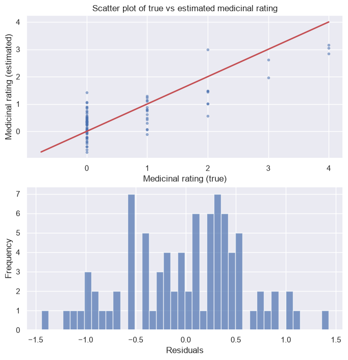

```python
# Fit regression model to the whiskey dataset
X_m = df.drop(columns=["RowID", "Distillery","Medicinal", "Postcode", " Latitude", " Longitude"])

X_tilde = np.column_stack([np.ones(len(X_m)), X_m])  # Add intercept term
y = df['Medicinal']

# YOUR CODE HERE
w_star = np.linalg.solve(X_tilde.T @ X_tilde, X_tilde.T @ y)
y_est = X_tilde @ w_star
residual = y_est - y

# Display scatter plot and histogram of residuals
fig, axs = plt.subplots(2, 1, figsize=(8, 8))
axs[0].scatter(y, y_est, marker='.', alpha=0.5)
min_val = min(y.min(), y_est.min())
max_val = max(y.max(), y_est.max())
axs[0].plot([min_val, max_val], [min_val, max_val], 'r-', linewidth=2)
axs[0].set_xlabel("Medicinal rating (true)")
axs[0].set_ylabel("Medicinal rating (estimated)")
axs[0].set_title("Scatter plot of true vs estimated medicinal rating")
axs[1].hist(residual, bins=40, alpha=0.7)
axs[1].set_xlabel("Residuals")
axs[1].set_ylabel("Frequency")

# Print estimated parameters
print(f"w* (incl bias): {np.array2string(w_star)}")
print(f"\nMSE: {np.mean(residual**2):.3f}")
```

```python
# Test for Assignment 5.1 (OLS and predictions)
with utils.marks(1):
    assert w_star.shape[0] == X_tilde.shape[1], "w_star should have one entry per column of X_tilde"
    assert len(y_est) == len(y), "y_est should have same length as y"
    assert len(residual) == len(y), "residual should have same length as y"
    MSE = np.mean(residual**2)
    assert np.isfinite(MSE) and MSE >= 0, "MSE should be finite and non-negative"
    assert utils.check_scalar(float(MSE), "0x4fa361b")
```

✓ [1 marks]

**Assignment 5.2:** Look at the scatter plot of true vs estimated medicinal rating and the histogram of residuals. In a short paragraph, comment on how well the linear model fits the data and what the residuals tell you (e.g. constant variance, outliers, possible non-linearity).

- *Answer (max 200 words)*

A linear regression might not be a great fit for this problem. It has an MSE of 0.34, and if we take the square root of that, it tells us our predictions are roughly 0.6 off on the 0 to 4 scale.

From the scatter plot we can see that higher values are estimated lower than their true value. For instance, whiskies with a true score of 4 are estimated to be around 3. Whiskies with a score of 0 are on average estimated slightly too high.

The residuals don't show any big outliers, since all errors are between about -1.4 and 1.4.

```python
# A manual test to be assessed by the teaching assistants (not auto-graded)
with utils.marks(1, auto=False, visible=False):
    print("Manual test")
```

? [manual assessment: 1 marks]

```
Manual test
```

**Assignment 5.3 (Logistic – data):** Using the `islay_whiskies` list from the data-loading cell, construct the binary target vector `y` (1 if the distillery is in that list, 0 otherwise) and the design matrix `X_tilde` (flavour columns plus intercept column of ones). Do not use sklearn.

```python
# Assignment 5.3: Build y and X_tilde for Islay classification
y = np.array([1 if d in islay_whiskies else 0 for d in distilleries], dtype=float).reshape(-1, 1)

# YOUR CODE HERE
X_tilde = np.column_stack([np.ones(len(X)), X])
print(X_tilde)
```

```
[[1. 2. 2. ... 2. 2. 2.]
 [1. 3. 3. ... 3. 3. 2.]
 [1. 1. 3. ... 2. 3. 2.]
 ...
 [1. 0. 3. ... 2. 1. 2.]
 [1. 2. 2. ... 1. 0. 0.]
 [1. 2. 3. ... 2. 2. 1.]]
```

```python
# Test for Assignment 5.3 (y, X_tilde)
with utils.marks(1):
    assert utils.check_hash(y, ((86, 1), 145.32452211976985))
    assert utils.check_hash(X_tilde, ((86, 13), 847437.3461418484))
```

✓ [1 marks]

**Assignment 5.4 (Logistic – fit and predict):**

- Find the weights in the logistic regression model

  > *Hint*: Reimplement, copy, or even better simply reuse the `fit_lr` function from **Task 4.3.7** to find the weights in a logistic regression model. **The tests below are made with `n_iter=20000` and otherwise default settings to `fit_lr`.**

  > *Hint*: If you use other built-in functions, the test will likely fail, but you will get full marks if done correctly (however be careful with the parameters to these functions!)
- Compute the probability of each whiskey being from Islay in `y_est_islay_prob` and the predicted class in `y_est`.

  > *Hint*: You can use the `p_y_given_w_and_x` and `predict` from Task 4.3 and 4.6, respectively.

```python
# Assignment 5.4: Fit model and compute y_est_islay_prob, y_est
# YOUR CODE HERE

def sigmoid(z):
    return 1 / (1 + np.exp(-z))

def p_y_given_w_and_x(w, X, y):
    p_y_is_one_given_x = sigmoid(X @ w)
    p = y*p_y_is_one_given_x + (1-y)*(1-p_y_is_one_given_x)
    return p

def loss_lr(w, X, y):
    es = -np.log(p_y_given_w_and_x(w, X, y))
    e = np.sum(es) / X.shape[0]
    return e

def loss_and_gradient_lr(w, X, y):
    N = X.shape[0]
    e = loss_lr(w, X, y)
    p_hat = p_y_given_w_and_x(w, X, np.ones((N, 1)))  # p(y=1 | w, x) for all the x entries
    g = (1/N) * X.T @ (p_hat - y)
    return e, g

def fit_lr(X, y, eta=0.001, n_iter=10000, eta_adaptive=True):
    N, M = X.shape
    w = np.zeros((M, 1))

    print("Iter\tLoss\t\t||grad||\t eta\t\t ||w||")
    print("-" * 60)
    e_prev = np.inf

    for iter in range(n_iter):
        e, gradient = loss_and_gradient_lr(w, X, y)

        # Now update the weights...
        w -= eta * gradient

        # We implement a simple way to control the learning rate for faster convergence
        if eta_adaptive:
            eta = eta * 0.5 if e > e_prev else eta * 1.005
            e_prev = e

        if iter % 100 == 0 or iter == n_iter - 1 or iter == 0:
            print(f"{iter}\t{e:.6f}\t{np.linalg.norm(gradient):.6f}\t{eta:.6f}\t{np.linalg.norm(w):.6f}")
    return w

w_star = fit_lr(X_tilde, y, n_iter=20000)
y_est_islay_prob = p_y_given_w_and_x(w_star, X_tilde, np.ones((X_tilde.shape[0], 1)))
y_est = (y_est_islay_prob >= 0.5).astype(int)
```

```
Iter	Loss		||grad||	 eta		 ||w||
------------------------------------------------------------
0	0.693147	2.336674	0.001005	0.002337
100	0.366505	1.002583	0.001655	0.201519
200	0.271340	0.428156	0.002725	0.338203
300	0.239329	0.218406	0.004487	0.434386
400	0.220818	0.155076	0.007389	0.511733
500	0.202625	0.123743	0.012167	0.599190
600	0.184892	0.090887	0.020036	0.722960
700	0.169871	0.065163	0.032992	0.881814
800	0.156012	0.051428	0.054327	1.072148
900	0.140865	0.042342	0.089459	1.325654
1000	0.124772	0.032875	0.147309	1.689014
1100	0.109930	0.023781	0.242568	2.171428
1200	0.097613	0.016686	0.399430	2.751569
1300	0.087576	0.011830	0.657728	3.423926
1400	0.079063	0.008611	1.083060	4.215423
1500	0.071402	0.006481	1.783441	5.179408
1600	0.063954	0.005089	2.936736	6.394684
1700	0.059737	0.004531	1.196958	7.197145
1800	0.056804	0.004208	1.970993	7.817453
1900	0.052735	0.003819	3.245572	8.754231
2000	0.049735	0.003561	1.322834	9.496337
2100	0.047678	0.003394	2.178269	10.045590
2200	0.044672	0.003159	3.586887	10.901321
2300	0.042403	0.002987	1.461947	11.585073
2400	0.040792	0.002866	2.407343	12.104231
2500	0.038403	0.002690	3.964095	12.919937
2600	0.036693	0.002565	1.615690	13.532061
2700	0.035376	0.002469	2.660507	14.033610
2800	0.033408	0.002327	4.380972	14.824078
2900	0.032066	0.002231	1.785602	15.385176
3000	0.030962	0.002153	2.940294	15.874410
3100	0.029304	0.002036	4.841689	16.646686
3200	0.028232	0.001960	1.973381	17.163434
3300	0.027289	0.001894	3.249505	17.643625
3400	0.025866	0.001796	5.350857	18.402436
3500	0.025011	0.001737	2.180908	18.871665
3600	0.024192	0.001681	3.591233	19.345523
3700	0.022952	0.001596	5.913570	20.094882
```

[output cut: 41 more lines]

```
7900	0.005196	0.000385	5.935091	40.658869
8000	0.005085	0.000377	9.773128	40.950962
8100	0.004912	0.000365	16.093102	41.418928
8200	0.004680	0.000348	6.559245	42.065700
8300	0.004580	0.000341	10.800901	42.357253
8400	0.004424	0.000329	17.785504	42.824314
8500	0.004227	0.000315	7.249036	43.431579
8600	0.004137	0.000308	11.936759	43.723308
8700	0.003996	0.000298	19.655884	44.190585
8800	0.003818	0.000285	8.011367	44.798026
8900	0.003736	0.000279	13.192066	45.089792
9000	0.003608	0.000270	21.722960	45.557074
9100	0.003455	0.000258	8.853868	46.133434
9200	0.003380	0.000253	14.579386	46.425781
9300	0.003264	0.000244	24.007416	46.893920
```

```
9400	0.003125	0.000234	9.784969	47.471203
```

```
9500	0.003058	0.000229	16.112601	47.763981
9600	0.002953	0.000221	26.532112	48.232747
9700	0.002828	0.000212	10.813988	48.804579
9800	0.002767	0.000208	17.807053	49.097790
9900	0.002671	0.000201	29.322314	49.567193
10000	0.002559	0.000192	11.951222	50.133609
10100	0.002504	0.000188	19.679700	50.427266
10200	0.002417	0.000182	32.405942	50.897326
10300	0.002317	0.000174	13.208050	51.458346
10400	0.002266	0.000170	21.749280	51.752467
10500	0.002188	0.000165	35.813854	52.223217
10600	0.002096	0.000158	14.597051	52.784977
10700	0.002051	0.000154	24.036504	53.079454
10800	0.001979	0.000149	39.580153	53.550730
10900	0.001896	0.000143	16.132123	54.119186
11000	0.001854	0.000140	26.564259	54.413794
11100	0.001790	0.000135	43.742529	54.885247
11200	0.001717	0.000129	17.828629	55.435606
11300	0.001679	0.000127	29.357841	55.730677
11400	0.001621	0.000122	48.342632	56.202827
11500	0.001552	0.000117	19.703544	56.772231
11600	0.001518	0.000115	32.445206	57.067274
11700	0.001465	0.000111	53.426498	57.539360
11800	0.001404	0.000106	21.775632	58.102557
11900	0.001373	0.000104	35.857247	58.397666
12000	0.001325	0.000100	59.044999	58.869834
12100	0.001270	0.000096	24.065627	59.420924
12200	0.001242	0.000094	39.628110	59.716320
12300	0.001199	0.000091	65.254360	60.188917
12400	0.001150	0.000087	26.596445	60.740455
12500	0.001124	0.000085	43.795528	61.036077
12600	0.001085	0.000082	72.116716	61.509010
12700	0.001041	0.000079	29.393412	62.054848
12800	0.001018	0.000077	48.401206	62.350776
12900	0.000982	0.000074	79.700741	62.824172
13000	0.000942	0.000071	32.484517	63.370510
13100	0.000921	0.000070	53.491231	63.666688
13200	0.000889	0.000067	88.082325	64.140461
13300	0.000853	0.000065	35.900693	64.687232
13400	0.000834	0.000063	59.116540	64.983611
```

[output cut: 51 more lines]

```
18600	0.000148	0.000011	532.799964	87.743391
18700	0.000143	0.000011	217.159207	88.266503
18800	0.000139	0.000011	357.589224	88.566912
18900	0.000134	0.000010	588.830909	89.047162
19000	0.000129	0.000010	239.996363	89.558879
19100	0.000126	0.000010	395.194449	89.859853
19200	0.000122	0.000009	650.754247	90.340980
19300	0.000117	0.000009	265.235146	90.853593
19400	0.000115	0.000009	436.754358	91.155078
19500	0.000110	0.000008	719.189641	91.636998
19600	0.000106	0.000008	293.128121	92.156403
19700	0.000104	0.000008	482.684841	92.458215
19800	0.000100	0.000008	794.821919	92.940643
19900	0.000096	0.000007	323.954410	93.466555
19999	0.000094	0.000007	530.791562	93.764745
```

```python
# Test for Assignment 5.4 (y_est_islay_prob, y_est)
with utils.marks(1):
    assert utils.check_hash(y_est_islay_prob, ((86, 1), 145.49994993914572))
    assert utils.check_hash(y_est, ((86, 1), 145.32452211976985))
```

✓ [1 marks]

**Assignment 5.5 (Logistic – evaluation):** Compute and report the misclassification rate for your Islay classifier (store in `misclass_rate`). Optionally plot predicted probabilities by true class (Islay vs not Islay).

```
Overall misclassification rate: 0.0000
```

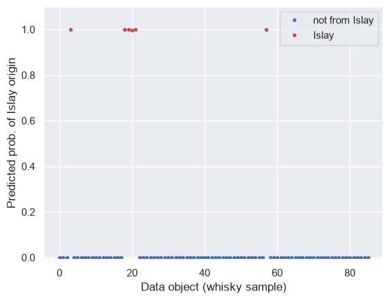

```python
# Assignment 5.5: Misclassification rate and optional plot
# YOUR CODE HERE
misclass_rate = np.mean(y_est != y)

print("\nOverall misclassification rate: {0:.4f}".format(misclass_rate))
f = plt.figure()
class0_ids = np.nonzero(y == 0)[0].tolist()
plt.plot(class0_ids, y_est_islay_prob[class0_ids], ".b")
class1_ids = np.nonzero(y == 1)[0].tolist()
plt.plot(class1_ids, y_est_islay_prob[class1_ids], ".r")
plt.xlabel("Data object (whisky sample)")
plt.ylabel("Predicted prob. of Islay origin")
plt.ylim(-0.01, 1.1)
plt.legend(["not from Islay", "Islay"])
```

```python
# Test for Assignment 5.5 (misclass_rate)
with utils.marks(1):
    assert 0 <= misclass_rate <= 1, "misclass_rate should be in [0,1]"
    assert utils.check_scalar(float(misclass_rate), "0x75c2e82a")
```

✓ [1 marks]

**Assignment 5.6:** We print the parameters in `w_star`. What does it tell you about Islay whiskies?

> *Hint*: It might look trivial, but a complete answer would consider the function, the current bias and weights, the sigmoid’s behavior, and the fact that the input features were neither centered nor standardized which is important when interpreting the weights.

```python
# Assignment 5.6: Print and interpret w_star for the Islay classifier (you do not need to code anything)
print("\033[1mEstimated parameters:\033[0;0m")
print(X.columns)
print(f"Weights (including bias term):\n {np.array2string(w_star)}")
```

```
Estimated parameters:
Index(['Body', 'Sweetness', 'Smoky', 'Medicinal', 'Tobacco', 'Honey', 'Spicy',
       'Winey', 'Nutty', 'Malty', 'Fruity', 'Floral'],
      dtype='str')
Weights (including bias term):
 [[-5.43744408e+01]
 [-4.64153442e+01]
 [-1.31438739e+01]
 [ 3.73961702e+01]
 [ 3.36665837e+01]
 [-7.11366347e+00]
 [ 9.14542982e+00]
 [ 2.14804367e+00]
 [ 5.06323492e-02]
 [-8.79761159e+00]
 [-9.64925224e+00]
 [ 7.58508744e-01]
 [ 2.58117910e+01]]
```

- *Answer (max 300 words; you can include latex or images of handwritten equations if needed)*:

The parameters reveal that Islay whiskies are mostly characterized by smoky and medicinal flavors, along with a lighter body and minimal sweetness. We can't directly compare the exact numbers, though, because the input isn't standardized. Like, if some features naturally have different bounds or vary more, we can't really compare them fairly to another feature. So we can't make a strict ranking of which feature counts the most. But just looking at the signs of the weights, we can definitely say that smoky and medicinal push the input towards being an Islay.

Also, the data wasn't centered, so the model starts with a huge negative bias (around -54). It basically assumes every whisky is not an Islay right out of the gate. To actually get classified as an Islay, a whisky has to have really strong scores in those features we just mentioned to overcome that big negative starting point.

Finally, the weights are really big, like 37 and 33. In logistic regression, this usually means the model separated the Islay whiskies from the others perfectly. This happens because of how the sigmoid function works.

```python
# A manual test to be assessed by the teaching assistants (not auto-graded)
with utils.marks(3, auto=False, visible=False):
    print("Manual test")
```

? [manual assessment: 3 marks]

```
Manual test
```

**Assignment 5.7:** Complete a function `confmat(actual, predicted)` that takes the true labels and predicted labels (as 1D arrays or column vectors of 0s and 1s) and returns a 2×2 confusion matrix (e.g. `confmat[i,j]` = count where actual class is `i` and predicted is `j`). Then create the confusion matrix for your Islay classifier.

> *Hint*: [A quick overview of confusion matrix](https://en.wikipedia.org/wiki/Confusion_matrix)

```
Confusion matrix:
[[80  0]
 [ 0  6]]
```

[figure not shown]

```python
# Confusion matrix
def confmat(actual, predicted):
    # initialize the confusion matrix
    confmat = np.zeros((2, 2), dtype=int)

    # Loop across the different combinations of actual / predicted classes
    for i in range(2):
        for j in range(2):

           # Count the number of instances in each combination of actual / predicted classes
           # YOUR CODE HERE
           confmat[i, j] = np.sum((np.ravel(actual) == i) & (np.ravel(predicted) == j))


    return confmat

# We print/plot the confusion matrix for you
accuracy = np.mean(y_est == y)
print("Confusion matrix:")
print(confmat(y, y_est))
cm = confmat(y, y_est)
# Plot the confusion matrix
fig = plt.figure(figsize=(8, 6))
ax = sns.heatmap(cm, annot=True, fmt='d', cmap="Blues", cbar=True,
    xticklabels=["Not Islay", "Islay"],
    yticklabels=["Not Islay", "Islay"]
)
ax.set_xlabel("Predicted class")
ax.set_ylabel("Actual class")
ax.set_title("Confusion matrix (Accuracy: {0}%)".format(accuracy))
plt.grid(False)
plt.show()
```

```python
# Test for Assignment 5.7 (confusion matrix)
with utils.marks(2):
    assert callable(confmat), "confmat should be a function"
    assert cm.shape == (2, 2), "Confusion matrix should be 2x2"
    assert np.issubdtype(cm.dtype, np.integer), "Confusion matrix should contain integers"
    assert np.sum(cm) == len(y), "Sum of confusion matrix should equal number of samples"
    assert utils.check_hash(cm, ((2, 2), 242.3636973763941))
```

✓ [2 marks]

**Assignment 5.8:** What does the confusion matrix tell us about the classifier?

- *Answer (max 100 words):*

THe matrix shows that all whiskies were classified correctly with 80 not islay whiskies and 6 silay whiskies. This answer is largely expected tho since its measured on the same data that it trained.

```python
# A manual test to be assessed by the teaching assistants (not auto-graded)
with utils.marks(1, auto=False, visible=False):
    print("Manual test")
```

? [manual assessment: 1 marks]

```
Manual test
```

**Assignment 5.9:** Provide a solution for the following question (an example of an exam question in a recent no aids exam), and explain your answer in detail.

Which one of the statements about logistic regression is *correct*?

> **A.** The logistic sigmoid function maps from a probability to a continuous value in $]-\infty,\infty[$.

> **B.** Logistic regression can be used to construct classifiers with nonlinear decision boundaries by considering nonlinear transformations of the inputs.

> **C.** Logistic regression minimizes the mean squared error between predicted probabilities and labels.

> **D.** The optimal weights for a logistic regression classifier can be always computed by $\boldsymbol{w}^* = (\tilde{\boldsymbol{X}}^\top \tilde{\boldsymbol{X}})^{-1} \tilde{\boldsymbol{X}}^\top\boldsymbol{y}$.

> **E.** Don't know.
- *Answer (max 200 words)*:

B. Logistic regressions wil have linear boundary unless applied a nonlinear feature transformation

```python
# A manual test to be assessed by the teaching assistants (not auto-graded)
with utils.marks(1, auto=False, visible=False):
    print("Manual test")
```

? [manual assessment: 1 marks]

```
Manual test
```

**Assignment 5.10:** Declaration on the use of AI for solving this assignment (mandatory)

Answer by replacing *[your answer here]* with your response.

1. *I abide by [DTU's code of honour](https://student.dtu.dk/en/exam/exam-cheating/dtu-code-of-honour) and take full responsibility for the content of this submission (yes / no)*:
   - yes
2. *To what extent did you use generative AI to solve this assignment (0-100%)*:
   - 20%
3. *What was the primary use of generative AI, if any (writing / coding / other)*:
   - used in part to understand the some of the previous exercises to answer this one
4. *I feel I understand the key techniques/algorithms/methods/coding elements used in this exercise such that I can apply it in a **no aids** exam (yes/no)*:
   - yes

**Assignment 5.11:** To submit this notebook, upload both teh HTML adn ipynb notebook. Make sure you have run everything in the **Assignment**-part, and convert this notebook to an HTML file.

> *Hint:* Open the **command palette** in Visual Studio Code, by pressing `Cmd + Shift + P` on Mac or `Ctrl + Shift + P` on Windows.

> *Hint:* Search for `Jupyter: Export to HTML` and save the HTML file.

> *Hint:* If you are running the notebook in the browser via the Jupyter interface, go to `File`, then `Save` and choose `Save and Export Notebook` as and select HTML.

#### Summary of the points (only valid after rerunning the Assignment-part from scratch)

```python
utils.marks_summary()
```

Marks summary

| Category | Score |
| --- | --- |
| Visible marks | 6 / 6 |
| Hidden marks | ? / 0 |
| Manually graded marks | ? / 6 |
| Total | (6 + ?) / 12 |